# Polarization: Concepts and Empirical Data

Author

Jan Lorenz

```r
source("functions.R")
library(patchwork)
```

## Dispersion

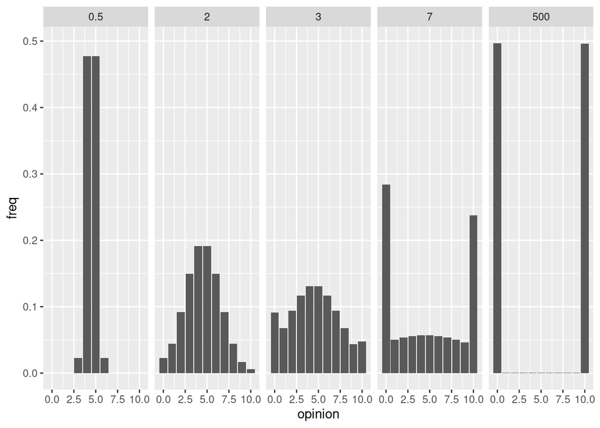

```r
expand_grid(sigma = c(0.5, 2,3,7,500), opinion = 0:10) |>
  mutate(freq = confined_discretized_dnorm(mean = 4.5, sd = mean(sigma)), .by = sigma) |>
  ggplot(aes(opinion,freq)) + geom_col() + facet_wrap(~sigma, ncol = 5)
```

## Within- and between-group polarization

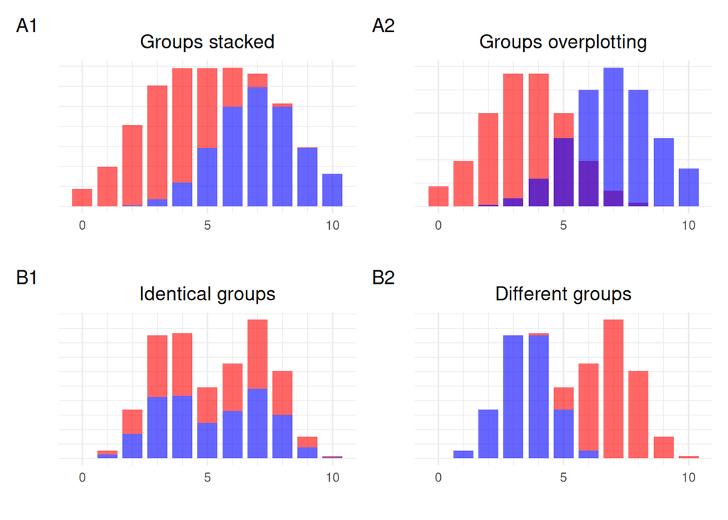

```r
o <- tibble(
 group = rep(c(1,2), each = 11),
 opinion = rep(0:10,2),
 freq = c(confined_discretized_dnorm(mean = 3.5, sd = 1.65)/2,
          confined_discretized_dnorm(mean = 7, sd = 1.65)/2)
)
stacked <- o |> ggplot(aes(opinion, freq, fill = factor(group))) + geom_col(width = 0.8, alpha = 0.6) +
 scale_fill_manual(values = c("red","blue")) +
 scale_x_continuous(breaks = c(0,5,10), minor_breaks = 0:10) +
 scale_y_continuous(breaks =c(), minor_breaks = seq(0,1,0.02)) +
 labs(x="", y="", title = "Groups stacked", tag = "A1") +
 theme_minimal() + guides(fill = "none") + theme(plot.title = element_text(hjust = 0.5))
side_by_side <- o |> ggplot(aes(opinion, freq, fill = factor(group))) +
 geom_col(position = position_identity(), width = 0.8, alpha = 0.6) +
 scale_fill_manual(values = c("red","blue")) +
 scale_x_continuous(breaks = c(0,5,10), minor_breaks = 0:10) +
 scale_y_continuous(breaks =c(), minor_breaks = seq(0,1,0.02)) +
 labs(x="", y="", title = "Groups overplotting", tag = "A2") +
 theme_minimal() + guides(fill = "none") + theme(plot.title = element_text(hjust = 0.5))
o <- tibble(
 group = rep(c(1,2), each = 11),
 opinion = rep(0:10,2),
 freq = c(confined_discretized_dnorm(mean = 7, sd = 1)/4 + confined_discretized_dnorm(mean = 3.5, sd = 1)/4,
          confined_discretized_dnorm(mean = 7, sd = 1)/4 + confined_discretized_dnorm(mean = 3.5, sd = 1)/4)
)
same <- o |> ggplot(aes(opinion, freq, fill = factor(group))) + geom_col(width = 0.8, alpha = 0.6) +
 scale_fill_manual(values = c("red","blue")) +
 scale_x_continuous(breaks = c(0,5,10), minor_breaks = 0:10) +
 scale_y_continuous(breaks =c(), minor_breaks = seq(0,1,0.02)) +
 labs(x="", y="", title = "Identical groups", tag = "B1") +
 theme_minimal() + guides(fill = "none") + theme(plot.title = element_text(hjust = 0.5))
o <- tibble(
 group = rep(c(1,2), each = 11),
 opinion = rep(0:10,2),
 freq = c(confined_discretized_dnorm(mean = 7, sd = 1)/2,
          confined_discretized_dnorm(mean = 3.5, sd = 1)/2)
)
different <- o |> ggplot(aes(opinion, freq, fill = factor(group))) +
 geom_col(width = 0.8, alpha = 0.6) +
 scale_fill_manual(values = c("red","blue")) +
 scale_x_continuous(breaks = c(0,5,10), minor_breaks = 0:10) +
 scale_y_continuous(breaks =c(), minor_breaks = seq(0,1,0.02)) +
 labs(x="", y="", title = "Different groups", tag = "B2") +
 theme_minimal() + guides(fill = "none") + theme(plot.title = element_text(hjust = 0.5))
stacked + side_by_side + same + different + plot_layout(nrow = 2)
```

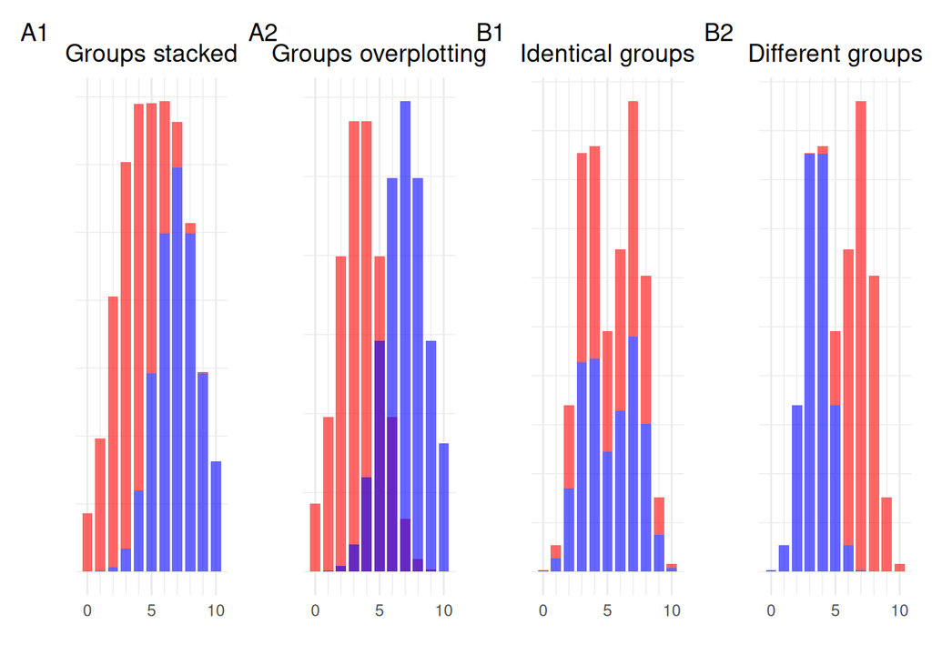

```r
ggsave("polarization_groupbased.pdf", width = 5, height = 4)
(stacked + side_by_side + same + different) + plot_layout(nrow = 1)
```

```r
ggsave("polarization_groupbased_wide.pdf", width = 9.5, height = 2.5)
```

## Examples

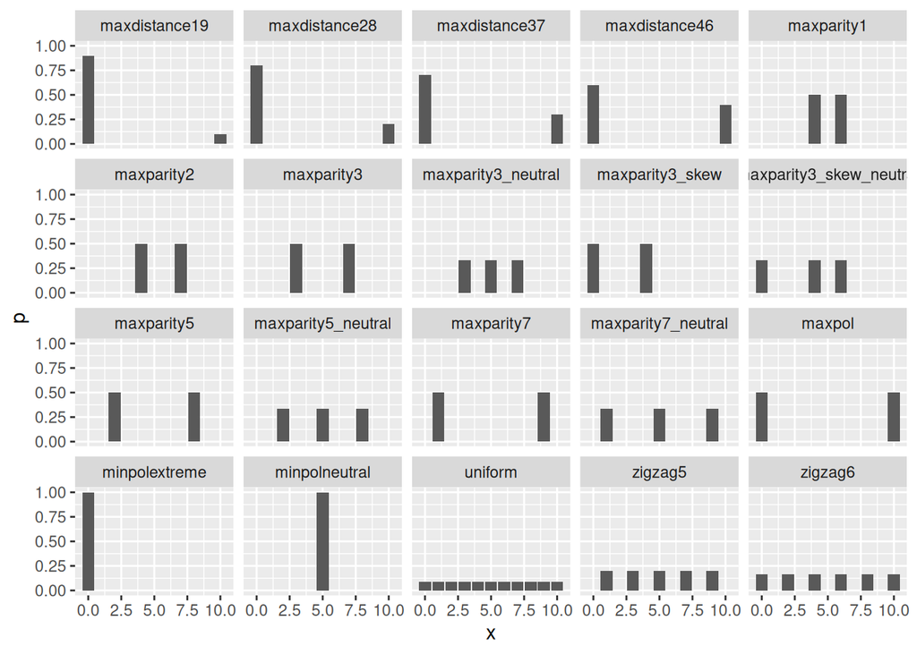

```r
# Example distributions
uniform <- rep(1,11)
maxparity1 <- c(0,0,0,0,1,0,1,0,0,0,0)
maxparity2 <- c(0,0,0,0,1,0,0,1,0,0,0)
maxparity3 <- c(0,0,0,1,0,0,0,1,0,0,0)
maxparity3_skew <- c(1,0,0,0,1,0,0,0,0,0,0)
maxparity5 <- c(0,0,1,0,0,0,0,0,1,0,0)
maxparity7 <- c(0,1,0,0,0,0,0,0,0,1,0)
maxparity3_neutral <- c(0,0,0,1,0,1,0,1,0,0,0)
maxparity3_skew_neutral  <- c(1,0,0,0,1,0,1,0,0,0,0)
maxparity5_neutral <- c(0,0,1,0,0,1,0,0,1,0,0)
maxparity7_neutral <- c(0,1,0,0,0,1,0,0,0,1,0)
maxdistance19 <- c(9,rep(0,9),1)
maxdistance28 <- c(8,rep(0,9),2)
maxdistance37 <- c(7,rep(0,9),3)
maxdistance46 <- c(6,rep(0,9),4)
zigzag6 <- c(1,rep(c(0,1),5))
zigzag5 <- c(0,rep(c(1,0),5))
maxpol <- c(1,rep(0,9),1)
minpolneutral <- c(rep(0,5),1,rep(0,5))
minpolextreme <- c(1,rep(0,10))

# Test df
test_df <- tibble(maxpol, maxparity1, maxparity2, maxparity3, maxparity3_skew, maxparity5, maxparity7,
       maxparity3_neutral, maxparity3_skew_neutral, maxparity5_neutral, maxparity7_neutral,
       maxdistance19, maxdistance28, maxdistance37, maxdistance46,
       uniform, zigzag5, zigzag6,
       minpolneutral, minpolextreme, x = 0:10) |>
 pivot_longer(-x, names_to = "type", values_to = "p", cols_vary = "slowest") |>
 mutate(p = p/sum(p), .by = type)

test_df |> ggplot(aes(x,p)) + geom_col() + facet_wrap(~type)
```

```r
test_df |>
 summarize(dist_sd = dist_sd(p),
           dist_pol0 = dist_pol(p),
           dist_pol05 = dist_pol(p, alpha = 0.5),
           dist_pol1 = dist_pol(p, alpha = 1),
           dist_pol15 = dist_pol(p, alpha = 1.5),
           .by = type) |>
 knitr::kable()
```

| type | dist_sd | dist_pol0 | dist_pol05 | dist_pol1 | dist_pol15 |
| --- | --- | --- | --- | --- | --- |
| maxpol | 1.0000000 | 1.0000000 | 1.0000000 | 1.0000000 | 1.0000000 |
| maxparity1 | 0.2000000 | 0.2000000 | 0.2000000 | 0.2000000 | 0.2000000 |
| maxparity2 | 0.3000000 | 0.3000000 | 0.3000000 | 0.3000000 | 0.3000000 |
| maxparity3 | 0.4000000 | 0.4000000 | 0.4000000 | 0.4000000 | 0.4000000 |
| maxparity3_skew | 0.4000000 | 0.4000000 | 0.4000000 | 0.4000000 | 0.4000000 |
| maxparity5 | 0.6000000 | 0.6000000 | 0.6000000 | 0.6000000 | 0.6000000 |
| maxparity7 | 0.8000000 | 0.8000000 | 0.8000000 | 0.8000000 | 0.8000000 |
| maxparity3_neutral | 0.3265986 | 0.3555556 | 0.2903099 | 0.2370370 | 0.1935399 |
| maxparity3_skew_neutral | 0.4988877 | 0.5333333 | 0.4354648 | 0.3555556 | 0.2903099 |
| maxparity5_neutral | 0.4898979 | 0.5333333 | 0.4354648 | 0.3555556 | 0.2903099 |
| maxparity7_neutral | 0.6531973 | 0.7111111 | 0.5806198 | 0.4740741 | 0.3870799 |
| maxdistance19 | 0.6000000 | 0.3600000 | 0.3219938 | 0.3600000 | 0.4507913 |
| maxdistance28 | 0.8000000 | 0.6400000 | 0.6071573 | 0.6400000 | 0.7285888 |
| maxdistance37 | 0.9165151 | 0.8400000 | 0.8222813 | 0.8400000 | 0.8909293 |
| maxdistance46 | 0.9797959 | 0.9600000 | 0.9551387 | 0.9600000 | 0.9744364 |
| uniform | 0.6324555 | 0.7272727 | 0.3101101 | 0.1322314 | 0.0563837 |
| zigzag5 | 0.5656854 | 0.6400000 | 0.4047715 | 0.2560000 | 0.1619086 |
| zigzag6 | 0.6831301 | 0.7777778 | 0.4490502 | 0.2592593 | 0.1496834 |
| minpolneutral | 0.0000000 | 0.0000000 | 0.0000000 | 0.0000000 | 0.0000000 |
| minpolextreme | 0.0000000 | 0.0000000 | 0.0000000 | 0.0000000 | 0.0000000 |

## Indices of Diversity and Concentration

The following measure are based on a set of $n$ labels (unordered categorical data) and a population where each individual has one of these labels such that we can call $p = [p_1,\dots,p_n]$ is a stochastic vector of frequencies how often each label appears in the population (thus $p_i \geq 0$ and $\sum_{i=1}^n p_i = 1$.

A common measure of *concentration* of labels is the Simpson index

It can be derived from a more general measure diversity

$$\text{D}_{\text{dis}}(p) = \sum_{i,j=1}^n p_ip_j \text{dis}(i,j)$$
where $\text{dis}(i,j)$ is the *discrepancy* (or *distance*, or *antagonism*) between labels $i$ and $j$. Discrepancy can be seen as a measure of distance between two label and is typically thought to be normalized such that the discrpancy between a label and itself is zero and the maximal distance between any two labels is one (if we have a bounded set of labels this does always exist). The simplest measure is *non-identity*

$$\text{non-id}(i,j) = \begin{cases} 0 & \text{if $i = j$} \\ 1 & \text{if $i \neq j$} \end{cases}$$

The diversity measure with $\text{non-id}$ is has vanishing terms if and only if $i=j$ so it is easy to see

$\text{Simpson}(p) = 1 - \text{D}_\text{non-id}(p)$.

In political science there is a directly related measure called the *effective number of parties* which we can re-label here more generally as the *effective number of labels*.

$$\text{effNum}(p) = \frac{1}{\text{Simpson}(p)}$$
It is easy to see that $\text{effNum}(p) = n$ when all labels have a equal share of $1/n$ in the population, while $\text{effNum}(p) = 1$ if and only if only one label is used such that $p_i = 0$ for all $i$ except one.